# Accident_Severity_Prediction

### The problem and a discussion

An accident could be happened to everyone at everytime in everywhere. But if we could collect the vast amount of accident data, we might be able to gain some insights that can be useful to reduce the number of accident or the fatality of the accident. There are many factors that are responsible for the existence of an accident, those are weather, road condition, light condition, etc. These factor can be strongly related to the severity of an accident, but some might be not. So, we need to find out what factor that directly related to the severity of an accident before predicting it.

In this project, we will try to predict the severity of an accident from the given dataset. This project will be a classification task where we will predict a categorical target.

### The description of the data

The dataset that we have to use in this project should contain factors that we have been explained above, so we use opensource data that can be found here [url]. These data consist of almost 200.000 observations and almost 40 columns. Lets begin by importing libraries and load our data.

|  | SEVERITYCODE | X | Y | OBJECTID | INCKEY | COLDETKEY | REPORTNO | STATUS | ADDRTYPE | INTKEY | LOCATION | EXCEPTRSNCODE | EXCEPTRSNDESC | SEVERITYCODE.1 | SEVERITYDESC | COLLISIONTYPE | PERSONCOUNT | PEDCOUNT | PEDCYLCOUNT | VEHCOUNT | INCDATE | INCDTTM | JUNCTIONTYPE | SDOT_COLCODE | SDOT_COLDESC | INATTENTIONIND | UNDERINFL | WEATHER | ROADCOND | … |
| --- | --- | --- | --- | --- | --- | --- | --- | --- | --- | --- | --- | --- | --- | --- | --- | --- | --- | --- | --- | --- | --- | --- | --- | --- | --- | --- | --- | --- | --- | --- |
| 0 | 2 | -122.323148 | 47.703140 | 1 | 1307 | 1307 | 3502005 | Matched | Intersection | 37475.0 | 5TH AVE NE AND NE 103RD ST |  | NaN | 2 | Injury Collision | Angles | 2 | 0 | 0 | 2 | 2013/03/27 00:00:00+00 | 3/27/2013 2:54:00 PM | At Intersection (intersection related) | 11 | MOTOR VEHICLE STRUCK MOTOR VEHICLE, FRONT END ... | NaN | N | Overcast | Wet | … |
| 1 | 1 | -122.347294 | 47.647172 | 2 | 52200 | 52200 | 2607959 | Matched | Block | NaN | AURORA BR BETWEEN RAYE ST AND BRIDGE WAY N | NaN | NaN | 1 | Property Damage Only Collision | Sideswipe | 2 | 0 | 0 | 2 | 2006/12/20 00:00:00+00 | 12/20/2006 6:55:00 PM | Mid-Block (not related to intersection) | 16 | MOTOR VEHICLE STRUCK MOTOR VEHICLE, LEFT SIDE ... | NaN | 0 | Raining | Wet | … |
| 2 | 1 | -122.334540 | 47.607871 | 3 | 26700 | 26700 | 1482393 | Matched | Block | NaN | 4TH AVE BETWEEN SENECA ST AND UNIVERSITY ST | NaN | NaN | 1 | Property Damage Only Collision | Parked Car | 4 | 0 | 0 | 3 | 2004/11/18 00:00:00+00 | 11/18/2004 10:20:00 AM | Mid-Block (not related to intersection) | 14 | MOTOR VEHICLE STRUCK MOTOR VEHICLE, REAR END | NaN | 0 | Overcast | Dry | … |
| 3 | 1 | -122.334803 | 47.604803 | 4 | 1144 | 1144 | 3503937 | Matched | Block | NaN | 2ND AVE BETWEEN MARION ST AND MADISON ST |  | NaN | 1 | Property Damage Only Collision | Other | 3 | 0 | 0 | 3 | 2013/03/29 00:00:00+00 | 3/29/2013 9:26:00 AM | Mid-Block (not related to intersection) | 11 | MOTOR VEHICLE STRUCK MOTOR VEHICLE, FRONT END ... | NaN | N | Clear | Dry | … |
| 4 | 2 | -122.306426 | 47.545739 | 5 | 17700 | 17700 | 1807429 | Matched | Intersection | 34387.0 | SWIFT AVE S AND SWIFT AV OFF RP | NaN | NaN | 2 | Injury Collision | Angles | 2 | 0 | 0 | 2 | 2004/01/28 00:00:00+00 | 1/28/2004 8:04:00 AM | At Intersection (intersection related) | 11 | MOTOR VEHICLE STRUCK MOTOR VEHICLE, FRONT END ... | NaN | 0 | Raining | Wet | … |
| ... | ... | ... | ... | ... | ... | ... | ... | ... | ... | ... | ... | ... | ... | ... | ... | ... | ... | ... | ... | ... | ... | ... | ... | ... | ... | ... | ... | ... | ... | … |
| 194668 | 2 | -122.290826 | 47.565408 | 219543 | 309534 | 310814 | E871089 | Matched | Block | NaN | 34TH AVE S BETWEEN S DAKOTA ST AND S GENESEE ST |  | NaN | 2 | Injury Collision | Head On | 3 | 0 | 0 | 2 | 2018/11/12 00:00:00+00 | 11/12/2018 8:12:00 AM | Mid-Block (not related to intersection) | 11 | MOTOR VEHICLE STRUCK MOTOR VEHICLE, FRONT END ... | NaN | N | Clear | Dry | … |
| 194669 | 1 | -122.344526 | 47.690924 | 219544 | 309085 | 310365 | E876731 | Matched | Block | NaN | AURORA AVE N BETWEEN N 85TH ST AND N 86TH ST |  | NaN | 1 | Property Damage Only Collision | Rear Ended | 2 | 0 | 0 | 2 | 2018/12/18 00:00:00+00 | 12/18/2018 9:14:00 AM | Mid-Block (not related to intersection) | 14 | MOTOR VEHICLE STRUCK MOTOR VEHICLE, REAR END | Y | N | Raining | Wet | … |
| 194670 | 2 | -122.306689 | 47.683047 | 219545 | 311280 | 312640 | 3809984 | Matched | Intersection | 24760.0 | 20TH AVE NE AND NE 75TH ST |  | NaN | 2 | Injury Collision | Left Turn | 3 | 0 | 0 | 2 | 2019/01/19 00:00:00+00 | 1/19/2019 9:25:00 AM | At Intersection (intersection related) | 11 | MOTOR VEHICLE STRUCK MOTOR VEHICLE, FRONT END ... | NaN | N | Clear | Dry | … |
| 194671 | 2 | -122.355317 | 47.678734 | 219546 | 309514 | 310794 | 3810083 | Matched | Intersection | 24349.0 | GREENWOOD AVE N AND N 68TH ST |  | NaN | 2 | Injury Collision | Cycles | 2 | 0 | 1 | 1 | 2019/01/15 00:00:00+00 | 1/15/2019 4:48:00 PM | At Intersection (intersection related) | 51 | PEDALCYCLIST STRUCK MOTOR VEHICLE FRONT END AT... | NaN | N | Clear | Dry | … |
| 194672 | 1 | -122.289360 | 47.611017 | 219547 | 308220 | 309500 | E868008 | Matched | Block | NaN | 34TH AVE BETWEEN E MARION ST AND E SPRING ST |  | NaN | 1 | Property Damage Only Collision | Rear Ended | 2 | 0 | 0 | 2 | 2018/11/30 00:00:00+00 | 11/30/2018 3:45:00 PM | Mid-Block (not related to intersection) | 14 | MOTOR VEHICLE STRUCK MOTOR VEHICLE, REAR END | NaN | N | Clear | Wet | … |

194673 rows × 38 columns

```
<class 'pandas.core.frame.DataFrame'>
RangeIndex: 194673 entries, 0 to 194672
Data columns (total 38 columns):
 #   Column          Non-Null Count   Dtype
---  ------          --------------   -----
 0   SEVERITYCODE    194673 non-null  int64
 1   X               189339 non-null  float64
 2   Y               189339 non-null  float64
 3   OBJECTID        194673 non-null  int64
 4   INCKEY          194673 non-null  int64
 5   COLDETKEY       194673 non-null  int64
 6   REPORTNO        194673 non-null  object
 7   STATUS          194673 non-null  object
 8   ADDRTYPE        192747 non-null  object
 9   INTKEY          65070 non-null   float64
```

[output cut: 30 more lines]

As we can see above, our data consist of many attributes that we don't even know at the first sight. The attributes such as "COLDETKEY", "INCKEY", etc, need detailed explanation, so I suggest you to download the metadata here [url].

After examining the attributes carefully, we decide to use only several attributes that are really related to the target data. Those are weather, road condition, light condition, juction type, inattention id, and speeding. So, we will use these attributes to predict how severe the accident will.

|  | SEVERITYCODE | JUNCTIONTYPE | UNDERINFL | WEATHER | ROADCOND | LIGHTCOND | INATTENTIONIND | SPEEDING |
| --- | --- | --- | --- | --- | --- | --- | --- | --- |
| 0 | 2 | At Intersection (intersection related) | N | Overcast | Wet | Daylight | NaN | NaN |
| 1 | 1 | Mid-Block (not related to intersection) | 0 | Raining | Wet | Dark - Street Lights On | NaN | NaN |
| 2 | 1 | Mid-Block (not related to intersection) | 0 | Overcast | Dry | Daylight | NaN | NaN |
| 3 | 1 | Mid-Block (not related to intersection) | N | Clear | Dry | Daylight | NaN | NaN |
| 4 | 2 | At Intersection (intersection related) | 0 | Raining | Wet | Daylight | NaN | NaN |
| ... | ... | ... | ... | ... | ... | ... | ... | ... |
| 194668 | 2 | Mid-Block (not related to intersection) | N | Clear | Dry | Daylight | NaN | NaN |
| 194669 | 1 | Mid-Block (not related to intersection) | N | Raining | Wet | Daylight | Y | NaN |
| 194670 | 2 | At Intersection (intersection related) | N | Clear | Dry | Daylight | NaN | NaN |
| 194671 | 2 | At Intersection (intersection related) | N | Clear | Dry | Dusk | NaN | NaN |
| 194672 | 1 | Mid-Block (not related to intersection) | N | Clear | Wet | Daylight | NaN | NaN |

194673 rows × 8 columns

After get our new dataset, the next thing we have to do is digging deeply. We can do this by show overall description of our dataset

```
<class 'pandas.core.frame.DataFrame'>
RangeIndex: 194673 entries, 0 to 194672
Data columns (total 8 columns):
 #   Column          Non-Null Count   Dtype
---  ------          --------------   -----
 0   SEVERITYCODE    194673 non-null  int64
 1   JUNCTIONTYPE    188344 non-null  object
 2   UNDERINFL       189789 non-null  object
 3   WEATHER         189592 non-null  object
 4   ROADCOND        189661 non-null  object
 5   LIGHTCOND       189503 non-null  object
 6   INATTENTIONIND  29805 non-null   object
 7   SPEEDING        9333 non-null    object
dtypes: int64(1), object(7)
memory usage: 11.9+ MB
```

|  | SEVERITYCODE | JUNCTIONTYPE | UNDERINFL | WEATHER | ROADCOND | LIGHTCOND | INATTENTIONIND | SPEEDING |
| --- | --- | --- | --- | --- | --- | --- | --- | --- |
| count | 194673.000000 | 188344 | 189789 | 189592 | 189661 | 189503 | 29805 | 9333 |
| unique | NaN | 7 | 4 | 11 | 9 | 9 | 1 | 1 |
| top | NaN | Mid-Block (not related to intersection) | N | Clear | Dry | Daylight | Y | Y |
| freq | NaN | 89800 | 100274 | 111135 | 124510 | 116137 | 29805 | 9333 |
| mean | 1.298901 | NaN | NaN | NaN | NaN | NaN | NaN | NaN |
| std | 0.457778 | NaN | NaN | NaN | NaN | NaN | NaN | NaN |
| min | 1.000000 | NaN | NaN | NaN | NaN | NaN | NaN | NaN |
| 25% | 1.000000 | NaN | NaN | NaN | NaN | NaN | NaN | NaN |
| 50% | 1.000000 | NaN | NaN | NaN | NaN | NaN | NaN | NaN |
| 75% | 2.000000 | NaN | NaN | NaN | NaN | NaN | NaN | NaN |
| max | 2.000000 | NaN | NaN | NaN | NaN | NaN | NaN | NaN |

From above description of our dataset, we can see that all the attributes are categorical data. So we should probably use bar chart tremendously. In addition, we can also easily know that there are missing values in our dataset, because each columns are not having equal count/value. Therefore we need to find out how many missing values in our datasets

```
SEVERITYCODE           0
JUNCTIONTYPE        6329
UNDERINFL           4884
WEATHER             5081
ROADCOND            5012
LIGHTCOND           5170
INATTENTIONIND    164868
SPEEDING          185340
dtype: int64
```

Should we directly remove the missing value? Nope. We want to know each columns' unique values first.

```
1    136485
2     58188
Name: SEVERITYCODE, dtype: int64

Mid-Block (not related to intersection)              89800
At Intersection (intersection related)               62810
Mid-Block (but intersection related)                 22790
Driveway Junction                                    10671
At Intersection (but not related to intersection)     2098
Ramp Junction                                          166
Unknown                                                  9
Name: JUNCTIONTYPE, dtype: int64

N    100274
0     80394
Y      5126
1      3995
Name: UNDERINFL, dtype: int64

Clear                       111135
Raining                      33145
Overcast                     27714
Unknown                      15091
Snowing                        907
Other                          832
Fog/Smog/Smoke                 569
Sleet/Hail/Freezing Rain       113
Blowing Sand/Dirt               56
Severe Crosswind                25
Partly Cloudy                    5
Name: WEATHER, dtype: int64

Dry               124510
Wet                47474
Unknown            15078
Ice                 1209
Snow/Slush          1004
Other                132
Standing Water       115
Sand/Mud/Dirt         75
Oil                   64
Name: ROADCOND, dtype: int64

Daylight                    116137
Dark - Street Lights On      48507
Unknown                      13473
Dusk                          5902
Dawn                          2502
Dark - No Street Lights       1537
Dark - Street Lights Off      1199
Other                          235
Dark - Unknown Lighting         11
Name: LIGHTCOND, dtype: int64

Y    29805
Name: INATTENTIONIND, dtype: int64

Y    9333
Name: SPEEDING, dtype: int64
```

There you go. We get 'unknown' value from several attributes that we have to take care of. How to fix that? Well, first of all we can change it into NaN value since we have no clue of that value and we have two option from that, which is remove it or fill it.

If you notice, in 'INATTENTIONID' and 'SPEEDING' columns, there is only 1 unique value, which is Y for yes and the rest of it is just Nan value. We pretty sure that this nan value should be N for no, so we simply change it from nan to no.

|  | SEVERITYCODE | JUNCTIONTYPE | UNDERINFL | WEATHER | ROADCOND | LIGHTCOND | INATTENTIONIND | SPEEDING |
| --- | --- | --- | --- | --- | --- | --- | --- | --- |
| 0 | 2 | At Intersection (intersection related) | N | Overcast | Wet | Daylight | N | N |
| 1 | 1 | Mid-Block (not related to intersection) | N | Raining | Wet | Dark - Street Lights On | N | N |
| 2 | 1 | Mid-Block (not related to intersection) | N | Overcast | Dry | Daylight | N | N |
| 3 | 1 | Mid-Block (not related to intersection) | N | Clear | Dry | Daylight | N | N |
| 4 | 2 | At Intersection (intersection related) | N | Raining | Wet | Daylight | N | N |
| ... | ... | ... | ... | ... | ... | ... | ... | ... |
| 194668 | 2 | Mid-Block (not related to intersection) | N | Clear | Dry | Daylight | N | N |
| 194669 | 1 | Mid-Block (not related to intersection) | N | Raining | Wet | Daylight | Y | N |
| 194670 | 2 | At Intersection (intersection related) | N | Clear | Dry | Daylight | N | N |
| 194671 | 2 | At Intersection (intersection related) | N | Clear | Dry | Dusk | N | N |
| 194672 | 1 | Mid-Block (not related to intersection) | N | Clear | Wet | Daylight | N | N |

194673 rows × 8 columns

After doing above cooking, we are clear to remove missing values or fill it, and we choose to remove it because the number is consideribly safe

|  | SEVERITYCODE | JUNCTIONTYPE | UNDERINFL | WEATHER | ROADCOND | LIGHTCOND | INATTENTIONIND | SPEEDING |
| --- | --- | --- | --- | --- | --- | --- | --- | --- |
| 0 | 2 | At Intersection (intersection related) | N | Overcast | Wet | Daylight | N | N |
| 1 | 1 | Mid-Block (not related to intersection) | N | Raining | Wet | Dark - Street Lights On | N | N |
| 2 | 1 | Mid-Block (not related to intersection) | N | Overcast | Dry | Daylight | N | N |
| 3 | 1 | Mid-Block (not related to intersection) | N | Clear | Dry | Daylight | N | N |
| 4 | 2 | At Intersection (intersection related) | N | Raining | Wet | Daylight | N | N |
| ... | ... | ... | ... | ... | ... | ... | ... | ... |
| 167992 | 2 | Mid-Block (not related to intersection) | N | Clear | Dry | Daylight | N | N |
| 167993 | 1 | Mid-Block (not related to intersection) | N | Raining | Wet | Daylight | Y | N |
| 167994 | 2 | At Intersection (intersection related) | N | Clear | Dry | Daylight | N | N |
| 167995 | 2 | At Intersection (intersection related) | N | Clear | Dry | Dusk | N | N |
| 167996 | 1 | Mid-Block (not related to intersection) | N | Clear | Wet | Daylight | N | N |

167997 rows × 8 columns

```
<class 'pandas.core.frame.DataFrame'>
RangeIndex: 167997 entries, 0 to 167996
Data columns (total 8 columns):
 #   Column          Non-Null Count   Dtype
---  ------          --------------   -----
 0   SEVERITYCODE    167997 non-null  object
 1   JUNCTIONTYPE    167997 non-null  object
 2   UNDERINFL       167997 non-null  object
 3   WEATHER         167997 non-null  object
 4   ROADCOND        167997 non-null  object
 5   LIGHTCOND       167997 non-null  object
 6   INATTENTIONIND  167997 non-null  object
 7   SPEEDING        167997 non-null  object
dtypes: object(8)
memory usage: 10.3+ MB
```

And we get our clean dataset that ready to be analyzed.

### Exploratory Data Analysis

In this section we will perform data analysis using univariate and bivariate technique. We are going to dive deep into this dataset and gain some insight before build our machine learning model.

#### Univariate Analysis

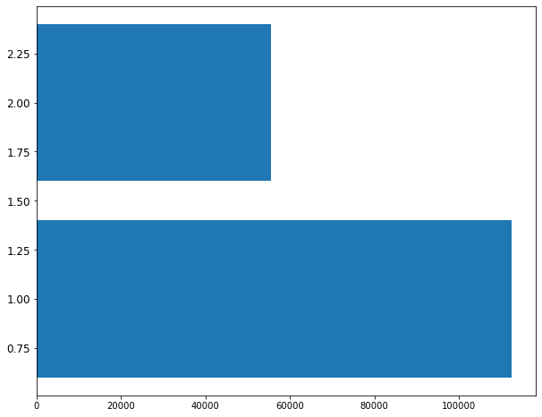

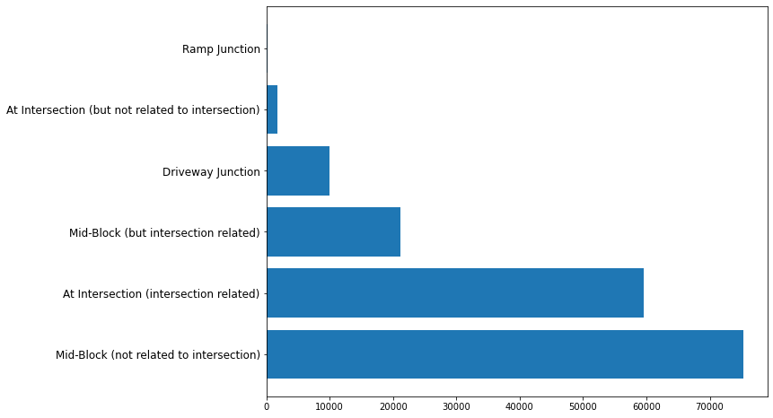

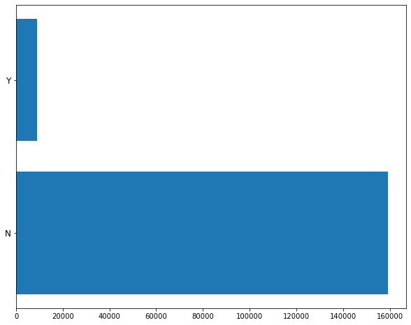

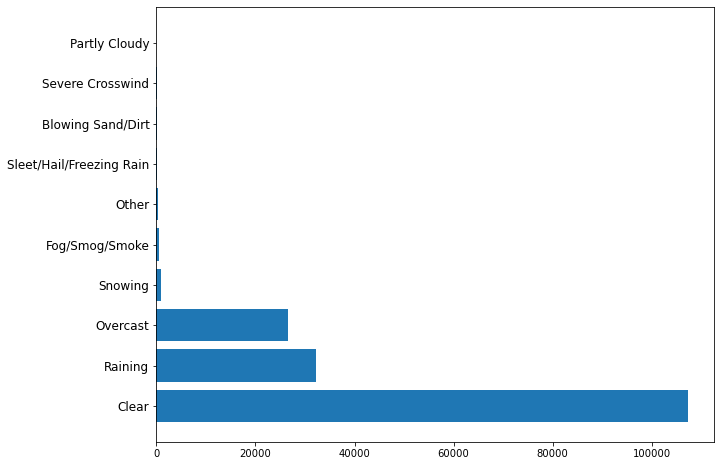

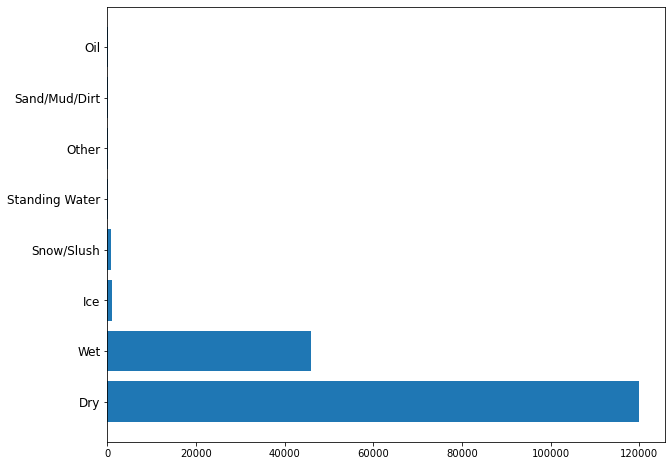

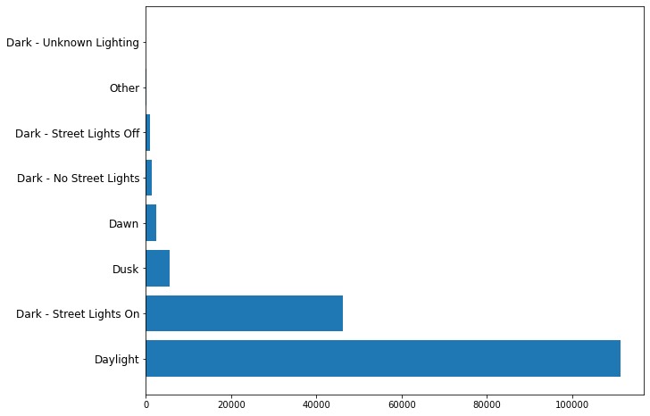

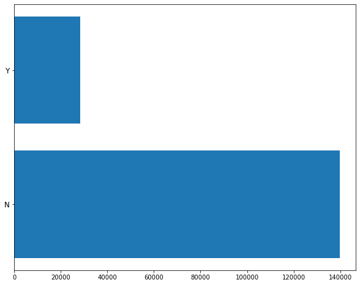

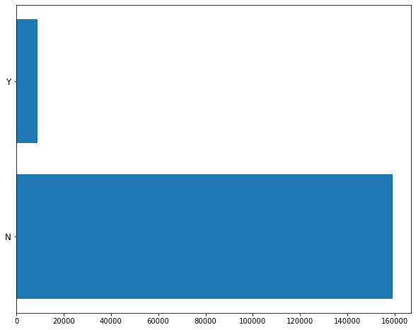

From visualizations above, we can see that low severity (code: 1) is dominating the data. This means the dataset have unbalance class/category in target variable. So we might want to balance that before put it into our model. Another insight from above figures is that the most accidents regardless its level of severity occured when the condition (weather, light, road, etc) seems normal. This is not we initially tought and we will see deeper analysis in the next part.

### Bivariate Analysis

```
              total                                                         \
ROADCOND        Dry  Ice Oil Other Sand/Mud/Dirt Snow/Slush Standing Water
SEVERITYCODE
1             80412  818  34    63            40        680             75
2             39486  263  24    42            21        156             30


ROADCOND        Wet
SEVERITYCODE
1             30360
2             15493
```

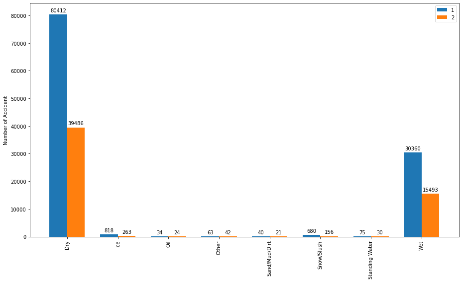

```
                               total                           \
LIGHTCOND    Dark - No Street Lights Dark - Street Lights Off
SEVERITYCODE
1                               1039                      783
2                                319                      307

                                                                             \
LIGHTCOND    Dark - Street Lights On Dark - Unknown Lighting  Dawn Daylight
SEVERITYCODE
1                              31935                       5  1578    73322
2                              14210                       4   805    37930


LIGHTCOND     Dusk Other
SEVERITYCODE
1             3684   136
2             1891    49
```

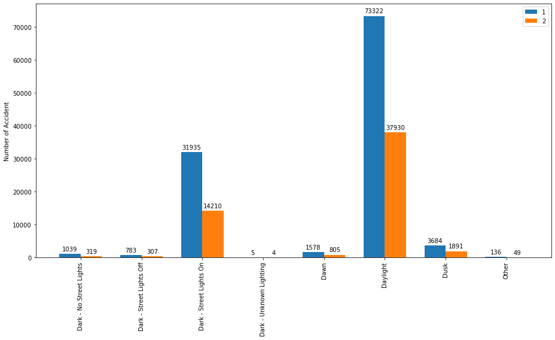

```
                         total                                       \
WEATHER      Blowing Sand/Dirt  Clear Fog/Smog/Smoke Other Overcast
SEVERITYCODE
1                           30  71898            361   172    17983
2                           13  35417            183    78     8588

                                                                              \
WEATHER      Partly Cloudy Raining Severe Crosswind Sleet/Hail/Freezing Rain
SEVERITYCODE
1                        2   21281               18                       83
2                        3   11035                7                       27


WEATHER      Snowing
SEVERITYCODE
1                654
2                164
```

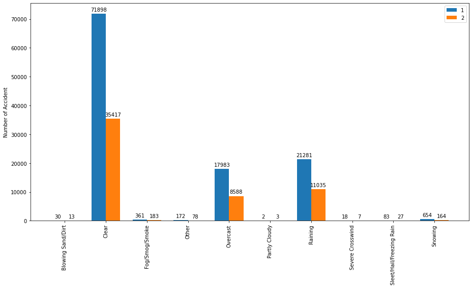

```
                                                         total  \
JUNCTIONTYPE At Intersection (but not related to intersection)
SEVERITYCODE
1                                                         1197
2                                                          601

                                                                       \
JUNCTIONTYPE At Intersection (intersection related) Driveway Junction
SEVERITYCODE
1                                             33278              6848
2                                             26243              3133

                                                   \
JUNCTIONTYPE Mid-Block (but intersection related)
SEVERITYCODE
1                                           14229
2                                            6986


JUNCTIONTYPE Mid-Block (not related to intersection) Ramp Junction
SEVERITYCODE
1                                              56825           105
2                                              18500            52
```

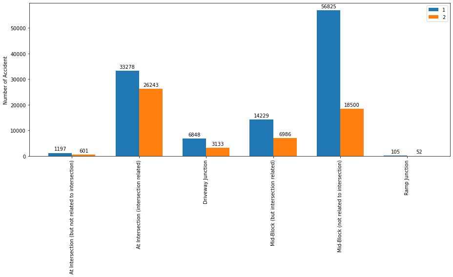

With bivariate analysis, we can see relationship between two variables. In this particular bivariate analysis, we only draw relationship between target variables (SEVERITYCODE) and its features. What we found is that every relationship above seems not too strong, so we have to use correlation to ensure this finding. But before we do that, we want to know what combination of features that has the highest count in this dataset.

|  | SEVERITYCODE | UNDERINFL | INATTENTIONIND | SPEEDING | WEATHER | ROADCOND | LIGHTCOND | JUNCTIONTYPE | total |
| --- | --- | --- | --- | --- | --- | --- | --- | --- | --- |
| 37 | 1 | N | N | N | Clear | Dry | Daylight | Mid-Block (not related to intersection) | 18208 |
| 34 | 1 | N | N | N | Clear | Dry | Daylight | At Intersection (intersection related) | 12593 |
| 1430 | 2 | N | N | N | Clear | Dry | Daylight | At Intersection (intersection related) | 10087 |
| 25 | 1 | N | N | N | Clear | Dry | Dark - Street Lights On | Mid-Block (not related to intersection) | 6501 |
| 1433 | 2 | N | N | N | Clear | Dry | Daylight | Mid-Block (not related to intersection) | 5368 |
| ... | ... | ... | ... | ... | ... | ... | ... | ... | ... |
| 1204 | 1 | Y | N | N | Raining | Wet | Dark - Street Lights Off | At Intersection (intersection related) | 1 |
| 1202 | 1 | Y | N | N | Raining | Wet | Dark - No Street Lights | At Intersection (intersection related) | 1 |
| 1201 | 1 | Y | N | N | Raining | Standing Water | Dark - Street Lights On | Mid-Block (not related to intersection) | 1 |
| 1198 | 1 | Y | N | N | Raining | Dry | Daylight | Mid-Block (not related to intersection) | 1 |
| 2435 | 2 | Y | Y | Y | Raining | Wet | Dusk | Mid-Block (not related to intersection) | 1 |

2436 rows × 9 columns

## Data Preprocessing

Before we go through to fit our data into our model, we need to preproccess our data. Turn every category into numerical data and get dummies.

|  | SEVERITYCODE | UNDERINFL | INATTENTIONIND | SPEEDING | JUNCTIONTYPE_At Intersection (but not related to intersection) | JUNCTIONTYPE_At Intersection (intersection related) | JUNCTIONTYPE_Driveway Junction | JUNCTIONTYPE_Mid-Block (but intersection related) | JUNCTIONTYPE_Mid-Block (not related to intersection) | JUNCTIONTYPE_Ramp Junction | WEATHER_Blowing Sand/Dirt | WEATHER_Clear | WEATHER_Fog/Smog/Smoke | WEATHER_Other | WEATHER_Overcast | WEATHER_Partly Cloudy | WEATHER_Raining | WEATHER_Severe Crosswind | WEATHER_Sleet/Hail/Freezing Rain | WEATHER_Snowing | ROADCOND_Dry | ROADCOND_Ice | ROADCOND_Oil | ROADCOND_Other | ROADCOND_Sand/Mud/Dirt | ROADCOND_Snow/Slush | ROADCOND_Standing Water | ROADCOND_Wet | LIGHTCOND_Dark - No Street Lights | … |
| --- | --- | --- | --- | --- | --- | --- | --- | --- | --- | --- | --- | --- | --- | --- | --- | --- | --- | --- | --- | --- | --- | --- | --- | --- | --- | --- | --- | --- | --- | --- |
| 0 | 1 | 0 | 0 | 0 | 0 | 1 | 0 | 0 | 0 | 0 | 0 | 0 | 0 | 0 | 1 | 0 | 0 | 0 | 0 | 0 | 0 | 0 | 0 | 0 | 0 | 0 | 0 | 1 | 0 | … |
| 1 | 0 | 0 | 0 | 0 | 0 | 0 | 0 | 0 | 1 | 0 | 0 | 0 | 0 | 0 | 0 | 0 | 1 | 0 | 0 | 0 | 0 | 0 | 0 | 0 | 0 | 0 | 0 | 1 | 0 | … |
| 2 | 0 | 0 | 0 | 0 | 0 | 0 | 0 | 0 | 1 | 0 | 0 | 0 | 0 | 0 | 1 | 0 | 0 | 0 | 0 | 0 | 1 | 0 | 0 | 0 | 0 | 0 | 0 | 0 | 0 | … |
| 3 | 0 | 0 | 0 | 0 | 0 | 0 | 0 | 0 | 1 | 0 | 0 | 1 | 0 | 0 | 0 | 0 | 0 | 0 | 0 | 0 | 1 | 0 | 0 | 0 | 0 | 0 | 0 | 0 | 0 | … |
| 4 | 1 | 0 | 0 | 0 | 0 | 1 | 0 | 0 | 0 | 0 | 0 | 0 | 0 | 0 | 0 | 0 | 1 | 0 | 0 | 0 | 0 | 0 | 0 | 0 | 0 | 0 | 0 | 1 | 0 | … |
| ... | ... | ... | ... | ... | ... | ... | ... | ... | ... | ... | ... | ... | ... | ... | ... | ... | ... | ... | ... | ... | ... | ... | ... | ... | ... | ... | ... | ... | ... | … |
| 167992 | 1 | 0 | 0 | 0 | 0 | 0 | 0 | 0 | 1 | 0 | 0 | 1 | 0 | 0 | 0 | 0 | 0 | 0 | 0 | 0 | 1 | 0 | 0 | 0 | 0 | 0 | 0 | 0 | 0 | … |
| 167993 | 0 | 0 | 1 | 0 | 0 | 0 | 0 | 0 | 1 | 0 | 0 | 0 | 0 | 0 | 0 | 0 | 1 | 0 | 0 | 0 | 0 | 0 | 0 | 0 | 0 | 0 | 0 | 1 | 0 | … |
| 167994 | 1 | 0 | 0 | 0 | 0 | 1 | 0 | 0 | 0 | 0 | 0 | 1 | 0 | 0 | 0 | 0 | 0 | 0 | 0 | 0 | 1 | 0 | 0 | 0 | 0 | 0 | 0 | 0 | 0 | … |
| 167995 | 1 | 0 | 0 | 0 | 0 | 1 | 0 | 0 | 0 | 0 | 0 | 1 | 0 | 0 | 0 | 0 | 0 | 0 | 0 | 0 | 1 | 0 | 0 | 0 | 0 | 0 | 0 | 0 | 0 | … |
| 167996 | 0 | 0 | 0 | 0 | 0 | 0 | 0 | 0 | 1 | 0 | 0 | 1 | 0 | 0 | 0 | 0 | 0 | 0 | 0 | 0 | 0 | 0 | 0 | 0 | 0 | 0 | 0 | 1 | 0 | … |

167997 rows × 36 columns

Relationship between attributes can be drawn by using pearson correlation like what we will do in following snippet.

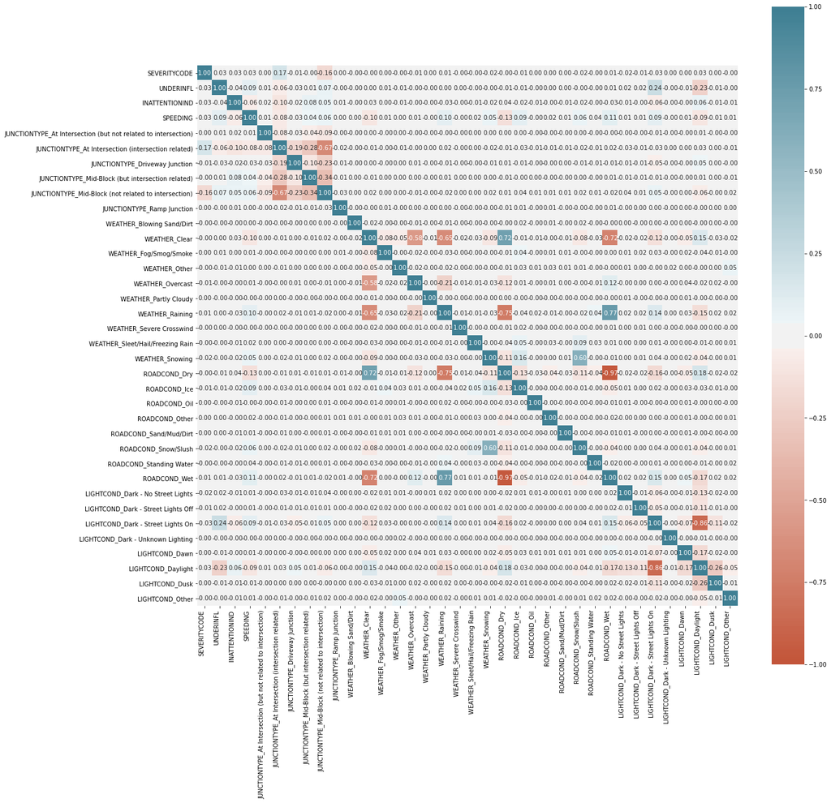

As we can see, above heatmap has conform our previous findings about weak relationship between target columns and features columns. So we should provide some treatments to the model that we want to apply.

```
Original dataset shape Counter({0: 112482, 1: 55515})
Resampled dataset shape Counter({1: 112482, 0: 112482})
```

### Building Model

In building model, we want to try every possible classifier model to fit into our dataset so that we can choose the best.

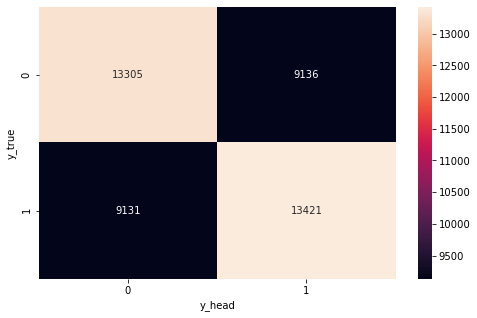

```
              precision    recall  f1-score   support

           0       0.59      0.59      0.59     22441
           1       0.59      0.60      0.60     22552

    accuracy                           0.59     44993
   macro avg       0.59      0.59      0.59     44993
weighted avg       0.59      0.59      0.59     44993
```

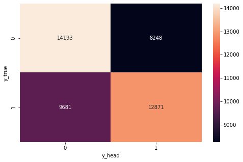

```
              precision    recall  f1-score   support

           0       0.59      0.63      0.61     22441
           1       0.61      0.57      0.59     22552

    accuracy                           0.60     44993
   macro avg       0.60      0.60      0.60     44993
weighted avg       0.60      0.60      0.60     44993
```

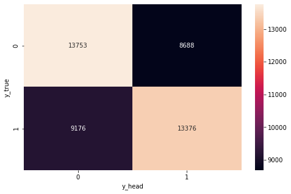

```
              precision    recall  f1-score   support

           0       0.60      0.61      0.61     22441
           1       0.61      0.59      0.60     22552

    accuracy                           0.60     44993
   macro avg       0.60      0.60      0.60     44993
weighted avg       0.60      0.60      0.60     44993
```

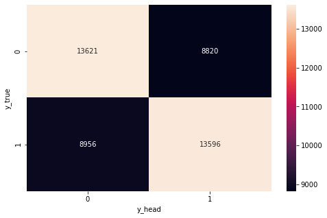

```
              precision    recall  f1-score   support

           0       0.60      0.61      0.61     22441
           1       0.61      0.60      0.60     22552

    accuracy                           0.60     44993
   macro avg       0.60      0.60      0.60     44993
weighted avg       0.60      0.60      0.60     44993
```

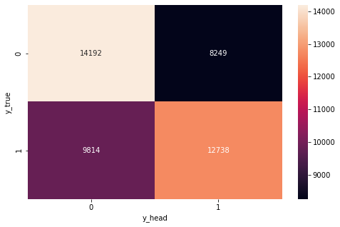

```
              precision    recall  f1-score   support

           0       0.59      0.63      0.61     22441
           1       0.61      0.56      0.59     22552

    accuracy                           0.60     44993
   macro avg       0.60      0.60      0.60     44993
weighted avg       0.60      0.60      0.60     44993
```

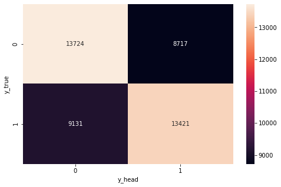

```
              precision    recall  f1-score   support

           0       0.60      0.61      0.61     22441
           1       0.61      0.60      0.60     22552

    accuracy                           0.60     44993
   macro avg       0.60      0.60      0.60     44993
weighted avg       0.60      0.60      0.60     44993
```

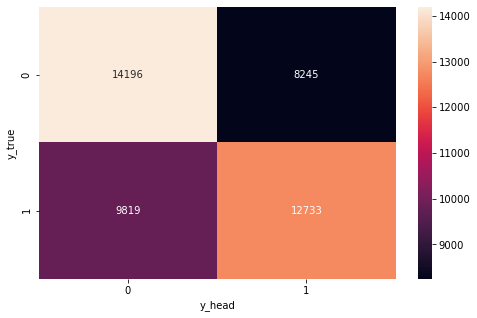

```
              precision    recall  f1-score   support

           0       0.59      0.63      0.61     22441
           1       0.61      0.56      0.59     22552

    accuracy                           0.60     44993
   macro avg       0.60      0.60      0.60     44993
weighted avg       0.60      0.60      0.60     44993
```

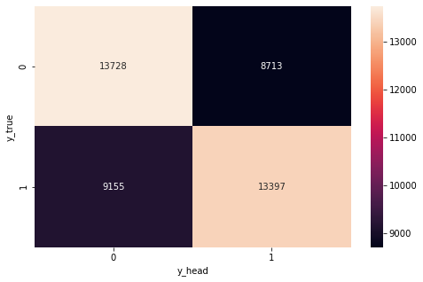

```
              precision    recall  f1-score   support

           0       0.60      0.61      0.61     22441
           1       0.61      0.59      0.60     22552

    accuracy                           0.60     44993
   macro avg       0.60      0.60      0.60     44993
weighted avg       0.60      0.60      0.60     44993
```

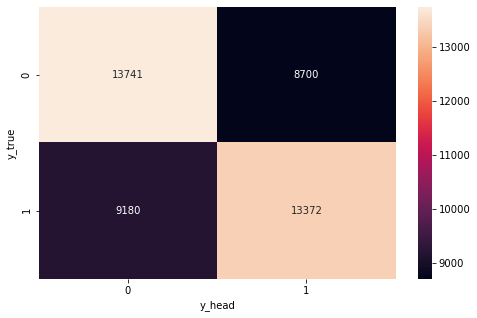

```
              precision    recall  f1-score   support

           0       0.60      0.61      0.61     22441
           1       0.61      0.59      0.60     22552

    accuracy                           0.60     44993
   macro avg       0.60      0.60      0.60     44993
weighted avg       0.60      0.60      0.60     44993
```

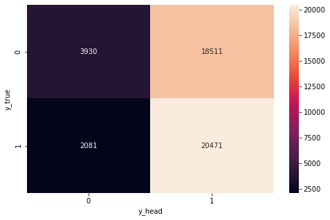

```
              precision    recall  f1-score   support

           0       0.65      0.18      0.28     22441
           1       0.53      0.91      0.67     22552

    accuracy                           0.54     44993
   macro avg       0.59      0.54      0.47     44993
weighted avg       0.59      0.54      0.47     44993
```

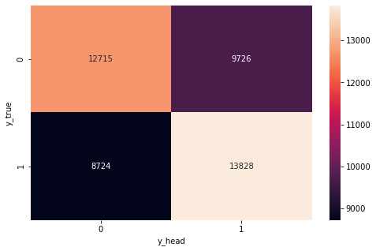

```
              precision    recall  f1-score   support

           0       0.59      0.57      0.58     22441
           1       0.59      0.61      0.60     22552

    accuracy                           0.59     44993
   macro avg       0.59      0.59      0.59     44993
weighted avg       0.59      0.59      0.59     44993
```

### Result Discussion

So, accuracy of our models was not considerably good. It was low and need further help, which we will do in the next part. But, what is it the reason for this to be happened? well, as we analyze the data before, we found that there was no strong relationship beetween target data and features data, so our models seemed confuse with the data.

### Optimizing Our Model

Our models did not really perform good. Probably because there is no strong relationship between target and features. Thus we have to optimizing our model.

```
Best Penalty: l2
Best C: 2.7825594022071245
```

```
0.5986042273242504
```

### Conclusion

1. We have successfully loaded the dataset from csv file
2. We have performed data cleaning in order to make our data suitable to the model
3. We have analyzed our data using various techniques where we found some odds and fixing it
4. We have preproccessed our dataset before being fitted into our model
5. We have built our model based on the dataset we have, where we were using classifier algorithm such as logistic regression, rando forest, decision tree, etc.
6. We have optimized our model in order to increase its accuracy using GridSearchCV and RandomizedCV
7. We could not meet the expected accuration rate and recommend to recollect or adjust the dataset.